# Analysis

### Risk framing

#### Per year

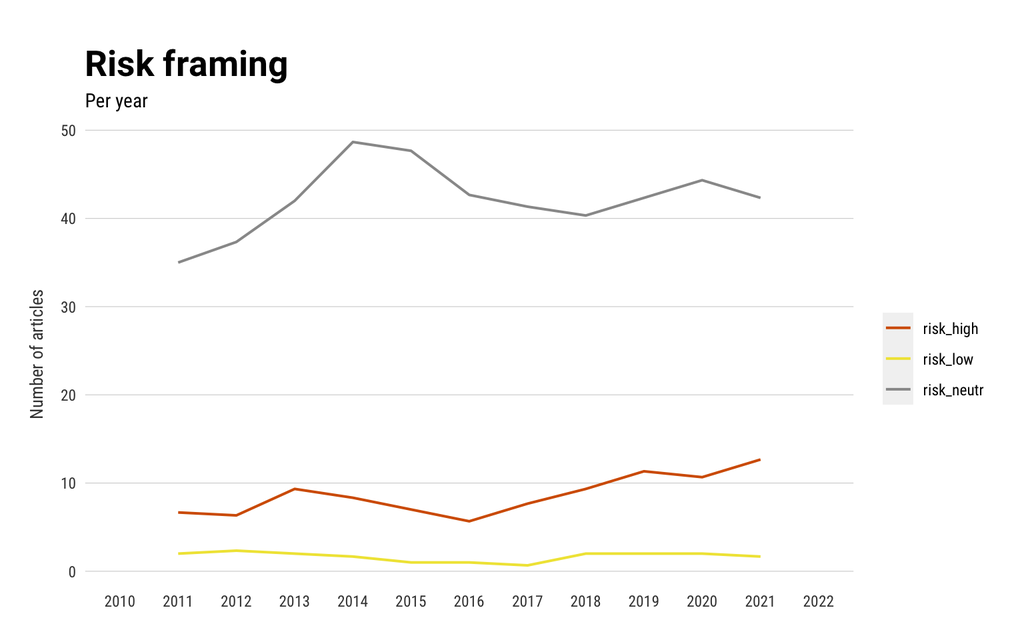

#### Per quarter

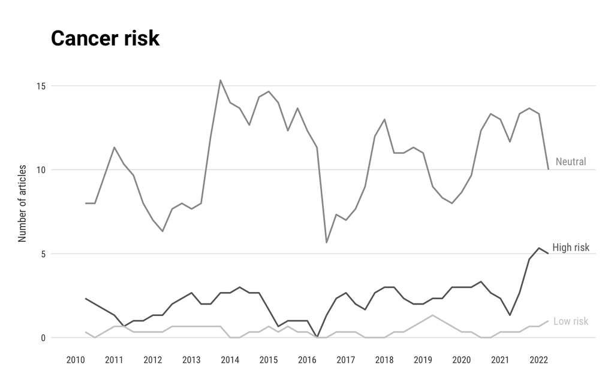

### Consequences framing

#### Per year

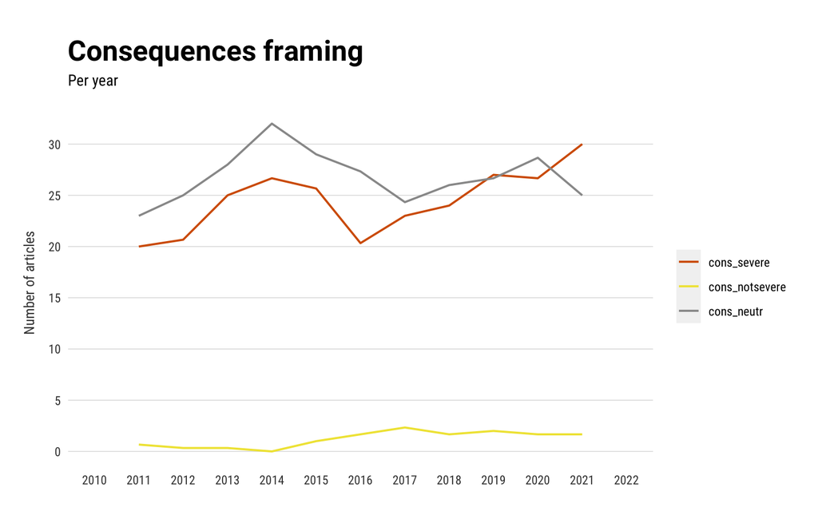

#### Per quarter

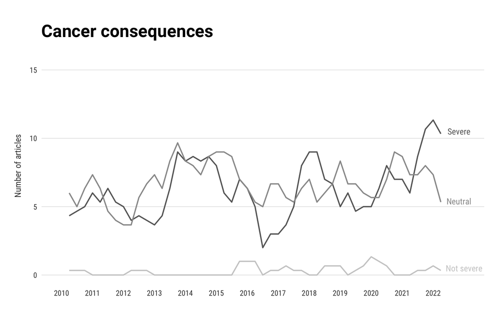

### Pros and cons (binary)

#### Per year

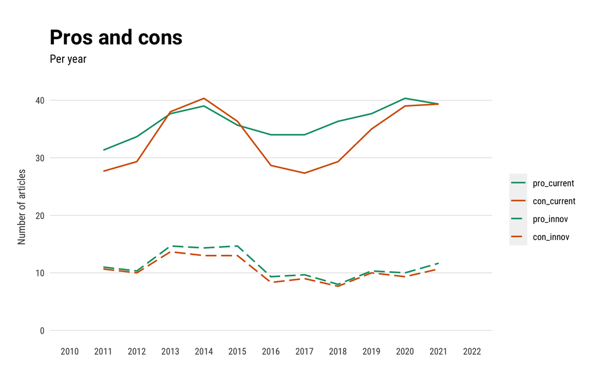

#### Per quarter

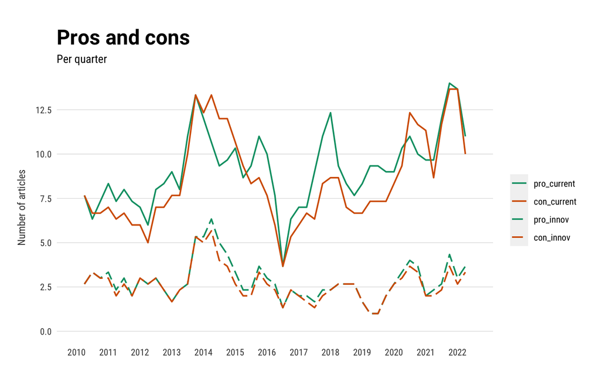

### News genre

#### Per year

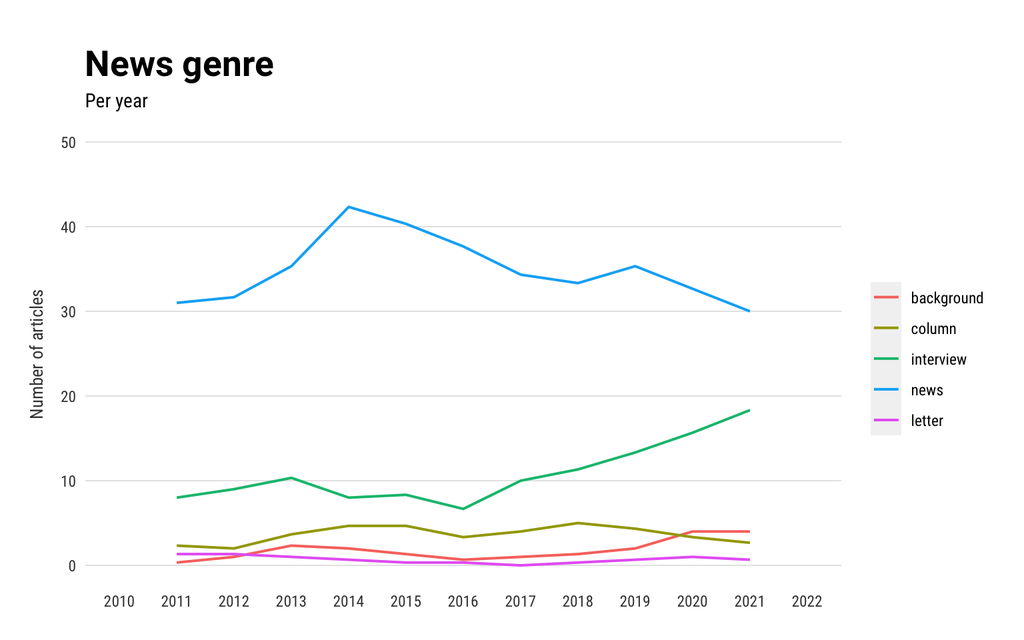

#### Per quarter

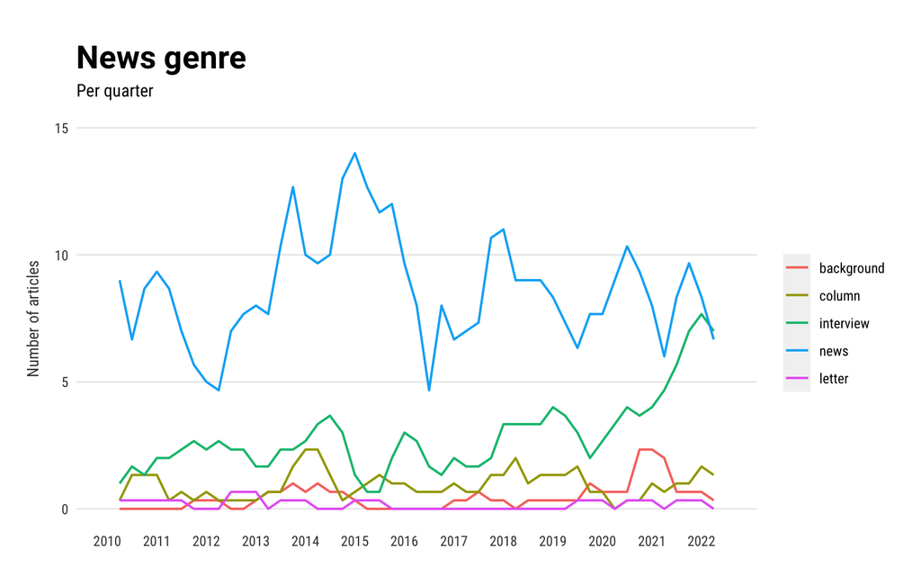

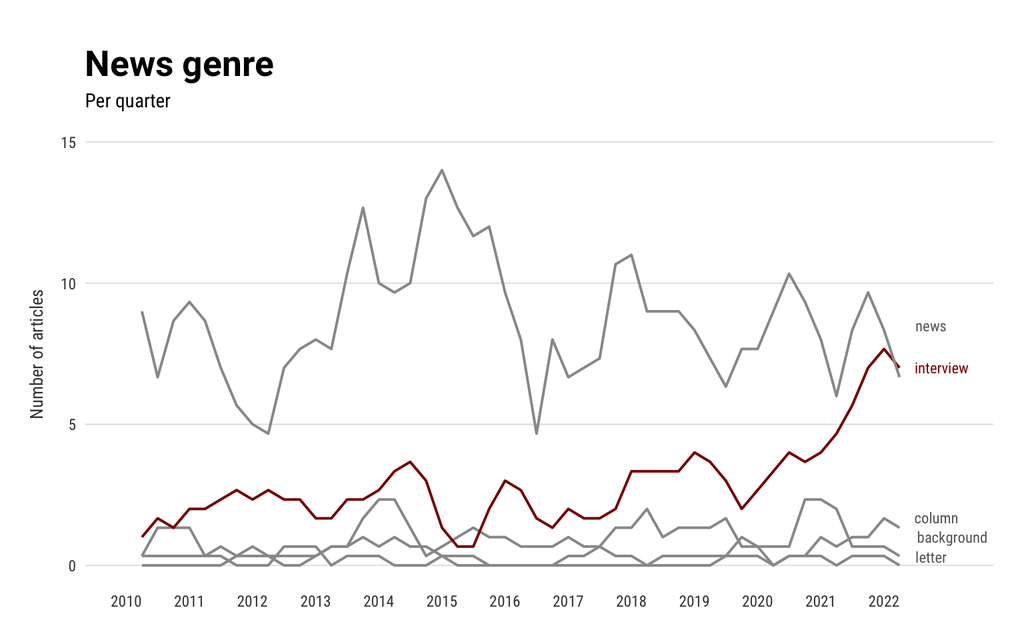

# Q3: Contextualization

## Sources

Which sources are quoted in news articles about cancer screening? And how does this relate to the extent to which screening effectiveness and cancer risks are discussed? E.g. is screening described as effective more frequently and cancer risks as higher for articles that quote individuals who are personally involved, whereas articles that quote healthcare professionals more frequently refer to the debate surrounding the effectiveness of screening?

### Sources - separate

If a source is present (vs. absent), then what is the likelihood that screening effectiveness, cancer risks and consequences are discussed (and in what direction).

Six groups of sources were coded:

- Health care professionals
- Science
- Health organizations
- Personal
- Politics
- Other

#### Effectiveness

|  | HCP n | HCP % | Science n | Science % | Organization n | Organization % | Personal n | Personal % | Politics n | Politics % | Other n | Other % |
| --- | --- | --- | --- | --- | --- | --- | --- | --- | --- | --- | --- | --- |
| Effectiviteit betwist | 55 | 31.43 | 66 | 41.25 | 31 | 19.50 | 24 | 16.90 | 12 | 17.39 | 14 | 22.95 |
| Expliciet effectief | 53 | 30.29 | 42 | 26.25 | 52 | 32.70 | 45 | 31.69 | 18 | 26.09 | 8 | 13.11 |
| Impliciet effectief | 48 | 27.43 | 34 | 21.25 | 58 | 36.48 | 56 | 39.44 | 26 | 37.68 | 23 | 37.70 |
| Neutraal | 19 | 10.86 | 18 | 11.25 | 18 | 11.32 | 17 | 11.97 | 13 | 18.84 | 16 | 26.23 |

#### Effectiveness - merged

|  | HCP n | HCP % | Science n | Science % | Organization n | Organization % | Personal n | Personal % | Politics n | Politics % | Other n | Other % |
| --- | --- | --- | --- | --- | --- | --- | --- | --- | --- | --- | --- | --- |
| Effectiviteit betwist | 55 | 31.43 | 66 | 41.25 | 31 | 19.50 | 24 | 16.90 | 12 | 17.39 | 14 | 22.95 |
| Effectief | 101 | 57.71 | 76 | 47.50 | 110 | 69.18 | 101 | 71.13 | 44 | 63.77 | 31 | 50.82 |
| Neutraal | 19 | 10.86 | 18 | 11.25 | 18 | 11.32 | 17 | 11.97 | 13 | 18.84 | 16 | 26.23 |

#### Risk

|  | HCP n | HCP % | Science n | Science % | Organization n | Organization % | Personal n | Personal % | Politics n | Politics % | Other n | Other % |
| --- | --- | --- | --- | --- | --- | --- | --- | --- | --- | --- | --- | --- |
| Neutral | 124 | 70.86 | 119 | 74.38 | 110 | 69.18 | 95 | 66.90 | 56 | 81.16 | 50 | 81.97 |
| High | 41 | 23.43 | 32 | 20.00 | 44 | 27.67 | 39 | 27.46 | 13 | 18.84 | 10 | 16.39 |
| Low | 10 | 5.71 | 9 | 5.62 | 5 | 3.14 | 8 | 5.63 | NA | NA | 1 | 1.64 |

#### Consequences

|  | HCP n | HCP % | Science n | Science % | Organization n | Organization % | Personal n | Personal % | Politics n | Politics % | Other n | Other % |
| --- | --- | --- | --- | --- | --- | --- | --- | --- | --- | --- | --- | --- |
| Neutral | 71 | 40.57 | 77 | 48.12 | 66 | 41.51 | 23 | 16.20 | 43 | 62.32 | 31 | 50.82 |
| Severe | 99 | 56.57 | 80 | 50.00 | 90 | 56.60 | 109 | 76.76 | 23 | 33.33 | 25 | 40.98 |
| Not severe | 5 | 2.86 | 3 | 1.87 | 3 | 1.89 | 10 | 7.04 | 3 | 4.35 | 5 | 8.20 |

### Sources - combined

Next, we compare whether the main categories (effectiveness, risk, consequences) are distributed differently for news articles in which differnet kinds of sources appear. Two professional sources are grouped as *professional* (i.e. healthcare professionsals, science) and compared to sources who share stories/information based on *personal* experiences.

(left out: politics, organization, and ‘other’)

- **Professional** = health care professional, science
- **Personal** = personal experience
- **Both** = professionals and personal experience

#### Effectiveness

##### Freqs

| effectiveness | Both n | Both % | None n | None % | Personal n | Personal % | Professional n | Professional % |
| --- | --- | --- | --- | --- | --- | --- | --- | --- |
| Effectiviteit betwist | 11 | 29.73 | 26 | 8.41 | 13 | 12.38 | 76 | 33.93 |
| Expliciet effectief | 11 | 29.73 | 108 | 34.95 | 34 | 32.38 | 68 | 30.36 |
| Impliciet effectief | 10 | 27.03 | 65 | 21.04 | 46 | 43.81 | 54 | 24.11 |
| Neutraal | 5 | 13.51 | 110 | 35.60 | 12 | 11.43 | 26 | 11.61 |

##### Chi

```
##
##  Pearson's Chi-squared test
##
## data:  df_incl$effectiveness and df_incl$source_combi
## X-squared = 109.17, df = 9, p-value < 2.2e-16
```

```
##                        df_incl$source_combi
## df_incl$effectiveness          Both        None    Personal Professional
##   Effectiviteit betwist  1.55755311 -4.17131077 -1.49078804   5.28687889
##   Expliciet effectief   -0.32008768  0.67915337 -0.06443139  -0.62346596
##   Impliciet effectief    0.13154093 -1.68830156  3.59900465  -0.53461086
##   Neutraal              -1.16943951  4.77476950 -2.41876418  -3.47669512
```

#### Effectiveness - merged

##### Freqs

| effectiveness_merged | Both n | Both % | None n | None % | Personal n | Personal % | Professional n | Professional % |
| --- | --- | --- | --- | --- | --- | --- | --- | --- |
| Effectiviteit betwist | 11 | 29.73 | 26 | 8.41 | 13 | 12.38 | 76 | 33.93 |
| Effectief | 21 | 56.76 | 173 | 55.99 | 80 | 76.19 | 122 | 54.46 |
| Neutraal | 5 | 13.51 | 110 | 35.60 | 12 | 11.43 | 26 | 11.61 |

##### Chi

```
##
##  Pearson's Chi-squared test
##
## data:  df_incl$effectiveness_merged and df_incl$source_combi
## X-squared = 98.675, df = 6, p-value < 2.2e-16
```

```
##                             df_incl$source_combi
## df_incl$effectiveness_merged       Both       None   Personal Professional
##        Effectiviteit betwist  1.5575531 -4.1713108 -1.4907880    5.2868789
##        Effectief             -0.1516764 -0.6149721  2.3443771   -0.8211523
##        Neutraal              -1.1694395  4.7747695 -2.4187642   -3.4766951
```

#### Risk

##### Freqs

| cancer_risk | Both n | Both % | None n | None % | Personal n | Personal % | Professional n | Professional % |
| --- | --- | --- | --- | --- | --- | --- | --- | --- |
| Neutral | 18 | 48.65 | 273 | 88.35 | 77 | 73.33 | 170 | 75.89 |
| High | 15 | 40.54 | 33 | 10.68 | 24 | 22.86 | 43 | 19.20 |
| Low | 4 | 10.81 | 3 | 0.97 | 4 | 3.81 | 11 | 4.91 |

##### Chi

Fisher’s exact with ‘low’

```
##
##  Fisher's Exact Test for Count Data
##
## data:  df_incl$cancer_risk and df_incl$source_combi
## p-value = 6.718e-08
## alternative hypothesis: two.sided
```

```
##                    df_incl$source_combi
## df_incl$cancer_risk       Both       None   Personal Professional
##             Neutral -2.1158940  1.7023377 -0.7311729   -0.6388608
##             High     3.4636694 -2.7074689  1.4448691    0.7829939
##             Low      2.5443544 -2.2281733  0.3123250    1.3690878
```

Chi with ‘low’ excluded

```
##
##  Pearson's Chi-squared test
##
## data:  df_q4_risk$cancer_risk and df_q4_risk$source_combi
## X-squared = 31.07, df = 3, p-value = 8.219e-07
```

```
##                       df_q4_risk$source_combi
## df_q4_risk$cancer_risk       Both       None   Personal Professional
##                Neutral -1.7621649  1.3156421 -0.6810776   -0.4143148
##                High     3.8114372 -2.8456402  1.4731223    0.8961334
```

#### Consequences

##### Freqs

| cancer_consequences | Both n | Both % | None n | None % | Personal n | Personal % | Professional n | Professional % |
| --- | --- | --- | --- | --- | --- | --- | --- | --- |
| Neutral | 7 | 18.92 | 208 | 67.31 | 16 | 15.24 | 109 | 48.66 |
| Severe | 28 | 75.68 | 100 | 32.36 | 81 | 77.14 | 111 | 49.55 |
| Not severe | 2 | 5.41 | 1 | 0.32 | 8 | 7.62 | 4 | 1.79 |

##### Chi

Fisher’s exact

```
##
##  Fisher's Exact Test for Count Data
##
## data:  df_incl$cancer_consequences and df_incl$source_combi
## p-value < 2.2e-16
## alternative hypothesis: two.sided
```

```
##                            df_incl$source_combi
## df_incl$cancer_consequences       Both       None   Personal Professional
##                  Neutral    -2.6955909  4.1965844 -5.0723984   -0.3605331
##                  Severe      2.4973359 -3.8410223  4.4253340    0.4665131
##                  Not severe  1.2988792 -2.2388161  3.7097041   -0.4382505
```

Chi with ‘not severe’ excluded

```
##
##  Pearson's Chi-squared test
##
## data:  df_q4_cons$cancer_consequences and df_q4_cons$source_combi
## X-squared = 93.525, df = 3, p-value < 2.2e-16
```

```
##                               df_q4_cons$source_combi
## df_q4_cons$cancer_consequences       Both       None   Personal Professional
##                        Neutral -2.5976817  3.9164953 -4.8054970   -0.4070458
##                        Severe   2.6776290 -4.0370310  4.9533930    0.4195732
```

#### Type of news article

The fact that we find differences for when both or none appear as sources in a news article, may be related to the fact that these reflect a different kind of journalistic genre (i.e. news article vs. background or interview). Therefore: extra test for genre X frames (efffectiveness, risk, consequences).

##### Freqs

| effectiveness | Interview n | Interview % | Column n | Column % | News n | News % |
| --- | --- | --- | --- | --- | --- | --- |
| Effectiviteit betwist | 14 | 29.79 | 26 | 17.81 | 71 | 16.10 |
| Effectief | 21 | 44.68 | 99 | 67.81 | 259 | 58.73 |
| Neutraal | 12 | 25.53 | 21 | 14.38 | 111 | 25.17 |

| Risk | Interview n | Interview % | Column n | Column % | News n | News % |
| --- | --- | --- | --- | --- | --- | --- |
| Neutral | 33 | 70.21 | 108 | 73.97 | 365 | 82.77 |
| High | 11 | 23.40 | 30 | 20.55 | 67 | 15.19 |
| Low | 3 | 6.38 | 8 | 5.48 | 9 | 2.04 |

| Consequences | Interview n | Interview % | Column n | Column % | News n | News % |
| --- | --- | --- | --- | --- | --- | --- |
| Neutral | 20 | 42.55 | 36 | 24.66 | 266 | 60.32 |
| Severe | 27 | 57.45 | 106 | 72.60 | 166 | 37.64 |
| Not severe | NA | NA | 4 | 2.74 | 9 | 2.04 |

##### Chi

```
##
##  Pearson's Chi-squared test
##
## data:  df_q4_extra$effectiveness_merged and df_q4_extra$newsgenre
## X-squared = 13.799, df = 4, p-value = 0.007965
```

```
##                        df_q4_extra$newsgenre
##                         Columns en opiniestukken
##   Effectiviteit betwist               2.01190450
##   Effectief                          -1.33876032
##   Neutraal                            0.40551272
##                        df_q4_extra$newsgenre
##                         Interview en persoonlijk verhaal Nieuwsbericht
##   Effectiviteit betwist                       0.08672858   -0.70670799
##   Effectief                                   1.25477264   -0.28492367
##   Neutraal                                   -2.11179655    1.08270855
```

[output not shown]

[output not shown]

```
##
##  Pearson's Chi-squared test
##
## data:  df_q4_extra_cons$cancer_consequences and df_q4_extra_cons$newsgenre
## X-squared = 57.925, df = 2, p-value = 2.64e-13
```

```
##          df_q4_extra_cons$newsgenre
##           Columns en opiniestukken Interview en persoonlijk verhaal
##   Neutral               -0.8852933                       -4.3853437
##   Severe                 0.9187123                        4.5508862
##          df_q4_extra_cons$newsgenre
##           Nieuwsbericht
##   Neutral     2.8062430
##   Severe     -2.9121760
```

## Risk and effectiveness frames

### Risk vs. consequence

Do news articles that mention the risks of cancer also refer to the severity of the consequences?

#### Freqs

Risk

| Consequences | Neutral n | Neutral % | High n | High % | Low n | Low % |
| --- | --- | --- | --- | --- | --- | --- |
| Neutral | 317 | 58.92 | 17 | 14.78 | 6 | 27.27 |
| Severe | 210 | 39.03 | 94 | 81.74 | 16 | 72.73 |
| Not severe | 11 | 2.04 | 4 | 3.48 | NA | NA |

#### Chi-square

“low” risk and consequence excluded

```
##
##  Pearson's Chi-squared test with Yates' continuity correction
##
## data:  df_q4_consrisk$cancer_risk and df_q4_consrisk$cancer_consequences
## X-squared = 72.105, df = 1, p-value < 2.2e-16
```

```
##
## df_q4_consrisk$cancer_risk   Neutral    Severe
##                    Neutral  2.475006 -2.594255
##                    High    -5.392872  5.652708
```

### Screening effectiveness vs. risk

When cancer risks are mentioned, is screening presented as an effective method to reduce cancer risks?

#### Effectiveness

##### Freqs

Effectiveness

| Risk | Betwist n | Betwist % | Effective:expl n | Effective:expl % | Effectiv:impl n | Effectiv:impl % | Neutral n | Neutral % |
| --- | --- | --- | --- | --- | --- | --- | --- | --- |
| Neutral | 86 | 68.25 | 161 | 72.85 | 144 | 82.29 | 147 | 96.08 |
| High | 31 | 24.60 | 53 | 23.98 | 25 | 14.29 | 6 | 3.92 |
| Low | 9 | 7.14 | 7 | 3.17 | 6 | 3.43 | NA | NA |

##### Chi-square

‘Low’ risk excluded

```
##
##  Pearson's Chi-squared test
##
## data:  df_q4_risk$effectiveness and df_q4_risk$cancer_risk
## X-squared = 34.603, df = 3, p-value = 1.478e-07
```

```
##                         df_q4_risk$cancer_risk
## df_q4_risk$effectiveness    Neutral       High
##    Effectiviteit betwist -1.0587689  2.2900417
##    Expliciet effectief   -1.1531929  2.4942741
##    Impliciet effectief    0.4036169 -0.8729945
##    Neutraal               1.8655092 -4.0349636
```

#### Effectiveness - merged

##### Freqs

Effectiveness_merged

| Risk | Betwist n | Betwist % | Effectief n | Effectief % | Neutral n | Neutral % |
| --- | --- | --- | --- | --- | --- | --- |
| Neutral | 86 | 68.25 | 305 | 77.02 | 147 | 96.08 |
| High | 31 | 24.60 | 78 | 19.70 | 6 | 3.92 |
| Low | 9 | 7.14 | 13 | 3.28 | NA | NA |

##### Chi-square

‘Low’ risk excluded

```
##
##  Pearson's Chi-squared test
##
## data:  df_q4_risk$effectiveness_merged and df_q4_risk$cancer_risk
## X-squared = 28.129, df = 2, p-value = 7.795e-07
```

```
##                        df_q4_risk$cancer_risk
##                            Neutral       High
##   Effectiviteit betwist -1.0587689  2.2900417
##   Effectief             -0.5938942  1.2845508
##   Neutraal               1.8655092 -4.0349636
```

### Effectiveness vs. consequences

#### Effectiveness

##### Freqs

Effectiveness

| Consequences | Betwist n | Betwist % | Effective:expl n | Effective:expl % | Effectiv:impl n | Effectiv:impl % | Neutral n | Neutral % |
| --- | --- | --- | --- | --- | --- | --- | --- | --- |
| Neutral | 47 | 37.30 | 67 | 30.32 | 92 | 52.57 | 134 | 87.58 |
| Severe | 75 | 59.52 | 149 | 67.42 | 78 | 44.57 | 18 | 11.76 |
| Not severe | 4 | 3.17 | 5 | 2.26 | 5 | 2.86 | 1 | 0.65 |

##### Chi-square

‘Not severe’ consequence excluded

```
##
##  Pearson's Chi-squared test
##
## data:  df_q4_cons$effectiveness and df_q4_cons$cancer_consequences
## X-squared = 126.75, df = 3, p-value < 2.2e-16
```

```
##                         df_q4_cons$cancer_consequences
## df_q4_cons$effectiveness    Neutral     Severe
##    Effectiviteit betwist -1.9991268  2.0606527
##    Expliciet effectief   -4.1970284  4.3261979
##    Impliciet effectief    0.4727668 -0.4873169
##    Neutraal               6.2942253 -6.4879389
```

#### Effectiveness - merged

##### Freqs

Effectiveness

| Consequences | Betwist n | Betwist % | Effectief n | Effectief % | Neutral n | Neutral % |
| --- | --- | --- | --- | --- | --- | --- |
| Neutral | 47 | 37.30 | 159 | 40.15 | 134 | 87.58 |
| Severe | 75 | 59.52 | 227 | 57.32 | 18 | 11.76 |
| Not severe | 4 | 3.17 | 10 | 2.53 | 1 | 0.65 |

##### Chi-square

‘Not severe’ consequence excluded

```
##
##  Pearson's Chi-squared test
##
## data:  df_q4_cons$effectiveness_merged and df_q4_cons$cancer_consequences
## X-squared = 106.42, df = 2, p-value < 2.2e-16
```

```
##                        df_q4_cons$cancer_consequences
##                           Neutral    Severe
##   Effectiviteit betwist -1.999127  2.060653
##   Effectief             -2.825860  2.912830
##   Neutraal               6.294225 -6.487939
```

## Pros and cons

Presence or absence per news article

### Pro vs con - current

#### Freqs

Pros

| Cons | Absent n | Absent % | Present n | Present % |
| --- | --- | --- | --- | --- |
| Absent | 105 | 50.48 | 137 | 29.34 |
| Present | 103 | 49.52 | 330 | 70.66 |

#### Chi-square

```
##
##  Pearson's Chi-squared test with Yates' continuity correction
##
## data:  df_incl$current_neg_bin and df_incl$current_pos_bin
## X-squared = 27.064, df = 1, p-value = 1.969e-07
```

```
##                        df_incl$current_pos_bin
## df_incl$current_neg_bin    Absent   Present
##                 Absent   3.523612 -2.351588
##                 Present -2.634218  1.758025
```

### Pro vs. con - innovative

#### Freqs

Pros

| Cons | Absent n | Absent % | Present n | Present % |
| --- | --- | --- | --- | --- |
| Absent | 526 | 99.43 | 13 | 8.9 |
| Present | 3 | 0.57 | 133 | 91.1 |

#### Chi-square

```
##
##  Fisher's Exact Test for Count Data
##
## data:  df_incl$innov_neg_bin and df_incl$innov_pos_bin
## p-value < 2.2e-16
## alternative hypothesis: true odds ratio is not equal to 1
## 95 percent confidence interval:
##   471.6894 8192.0000
## sample estimates:
## odds ratio
##   1716.035
```

```
##                      df_incl$innov_pos_bin
## df_incl$innov_neg_bin     Absent    Present
##               Absent    5.039891  -9.593399
##               Present -10.033352  19.098420
```

### Current vs. innovative

Pro, con, both, absent (4 levels)

#### Freqs - all

Current measures

| Innovative measures | Absent n | Absent % | Both n | Both % | Con n | Con % | Pro n | Pro % |
| --- | --- | --- | --- | --- | --- | --- | --- | --- |
| Absent | 99 | 94.29 | 214 | 64.85 | 80 | 77.67 | 133 | 97.08 |
| Both | 4 | 3.81 | 113 | 34.24 | 14 | 13.59 | 2 | 1.46 |
| Con | 2 | 1.90 | NA | NA | 1 | 0.97 | NA | NA |
| Pro | NA | NA | 3 | 0.91 | 8 | 7.77 | 2 | 1.46 |

#### Freqs - binary

Since oftentimes, pro and cons are given for current measures, this is changed to “procon” present vs. absent.

Current measures

| Innovative measures | Absent n | Absent % | Both n | Both % | Con n | Con % | Pro n | Pro % |
| --- | --- | --- | --- | --- | --- | --- | --- | --- |
| Absent | 99 | 94.29 | 214 | 64.85 | 80 | 77.67 | 133 | 97.08 |
| Present | 6 | 5.71 | 116 | 35.15 | 23 | 22.33 | 4 | 2.92 |

#### Chi-square

```
##
##  Fisher's Exact Test for Count Data
##
## data:  df_incl$innov_procon_bin and df_incl$current_procon
## p-value < 2.2e-16
## alternative hypothesis: two.sided
```

```
##                         df_incl$current_procon
## df_incl$innov_procon_bin      Absent        Both         Con         Pro
##                  Absent   1.89902790 -2.69115527 -0.02943450  2.53972726
##                  Present -3.56805124  5.05636590  0.05530398 -4.77185038
```

### Effectiveness vs. current pro/con

Pro, con, both, absent (4 levels)

#### Freqs

Current pros and cons

| effectiveness | Absent n | Absent % | Both n | Both % | Con n | Con % | Pro n | Pro % |
| --- | --- | --- | --- | --- | --- | --- | --- | --- |
| Effectiviteit betwist | 2 | 1.90 | 84 | 25.45 | 40 | 38.83 | NA | NA |
| Expliciet effectief | 1 | 0.95 | 130 | 39.39 | 5 | 4.85 | 85 | 62.04 |
| Impliciet effectief | 42 | 40.00 | 72 | 21.82 | 27 | 26.21 | 34 | 24.82 |
| Neutraal | 60 | 57.14 | 44 | 13.33 | 31 | 30.10 | 18 | 13.14 |

#### Chi-square

De tabel geeft met name inzicht hoe de coderingen zijn gedaan. Maar gezien er inhoudelijke overlap zit tussen de ‘effectiveness’ codering in het algemeen en de pros and cons op zinsniveau, heeft het geen zin om daar een chikwadraat over te berekenen.

# Q4: Differences between screening

NB: Chi-squares only between breast, cervical, and colon cancer. Frequencies for lung cancer and prostate cancer are too low.

## Framing

### Effectiveness

#### Freqs

##### Cervix-breast-colon

|  | Cervical n | Cervical % | Breast n | Breast % | Colon n | Colon % |
| --- | --- | --- | --- | --- | --- | --- |
| Effectiviteit betwist | 8 | 9.76 | 52 | 15.81 | 32 | 21.33 |
| Expliciet effectief | 29 | 35.37 | 110 | 33.43 | 52 | 34.67 |
| Impliciet effectief | 30 | 36.59 | 70 | 21.28 | 37 | 24.67 |
| Neutraal | 15 | 18.29 | 97 | 29.48 | 29 | 19.33 |

##### Lung-psa

|  | Lung n | Lung % | Prostate n | Prostate % |
| --- | --- | --- | --- | --- |
| Effectiviteit betwist | 1 | 10 | 18 | 64.29 |
| Expliciet effectief | 3 | 30 | 5 | 17.86 |
| Impliciet effectief | 5 | 50 | 3 | 10.71 |
| Neutraal | 1 | 10 | 2 | 7.14 |

#### Chisquare

```
##
##  Pearson's Chi-squared test
##
## data:  df_q3$effectiveness and df_q3$cancer_type
## X-squared = 16.915, df = 6, p-value = 0.009601
```

```
##                        df_q3$cancer_type
## df_q3$effectiveness     Baarmoederhalskanker Borstkanker  Darmkanker
##   Effectiviteit betwist          -1.48549461 -0.26597282  1.49223208
##   Expliciet effectief             0.20477817 -0.19015068  0.13020473
##   Impliciet effectief             2.22909750 -1.15401886  0.06096534
##   Neutraal                       -1.23565955  1.57368726 -1.41700764
```

### Effectiveness - effective merged

#### Freqs

##### Cervix-breast-colon

|  | Cervical n | Cervical % | Breast n | Breast % | Colon n | Colon % |
| --- | --- | --- | --- | --- | --- | --- |
| Effectiviteit betwist | 8 | 9.76 | 52 | 15.81 | 32 | 21.33 |
| Effectief | 59 | 71.95 | 180 | 54.71 | 89 | 59.33 |
| Neutraal | 15 | 18.29 | 97 | 29.48 | 29 | 19.33 |

##### Lung-psa

|  | Lung n | Lung % | Prostate n | Prostate % |
| --- | --- | --- | --- | --- |
| Effectiviteit betwist | 1 | 10 | 18 | 64.29 |
| Effectief | 8 | 80 | 8 | 28.57 |
| Neutraal | 1 | 10 | 2 | 7.14 |

#### Chisquare

```
##
##  Pearson's Chi-squared test
##
## data:  df_q3$effectiveness_merged and df_q3$cancer_type
## X-squared = 13.879, df = 4, p-value = 0.007693
```

```
##                           df_q3$cancer_type
## df_q3$effectiveness_merged Baarmoederhalskanker Borstkanker Darmkanker
##      Effectiviteit betwist           -1.4854946  -0.2659728  1.4922321
##      Effectief                        1.5968955  -0.8909273  0.1387598
##      Neutraal                        -1.2356595   1.5736873 -1.4170076
```

### Risk frame

#### Freqs

##### Cervix-breast-colon

|  | Cervical n | Cervical % | Breast n | Breast % | Colon n | Colon % |
| --- | --- | --- | --- | --- | --- | --- |
| Neutral | 64 | 78.05 | 281 | 85.41 | 115 | 76.67 |
| High | 11 | 13.41 | 42 | 12.77 | 29 | 19.33 |
| Low | 7 | 8.54 | 6 | 1.82 | 6 | 4.00 |

##### Lung-psa

|  | Lung n | Lung % | Prostate n | Prostate % |
| --- | --- | --- | --- | --- |
| Neutral | 3 | 30 | 17 | 60.71 |
| High | 7 | 70 | 10 | 35.71 |
| Low | NA | NA | 1 | 3.57 |

#### Chi-square

```
##
##  Pearson's Chi-squared test
##
## data:  df_q3$cancer_risk and df_q3$cancer_type
## X-squared = 13.239, df = 4, p-value = 0.01016
```

```
##                  df_q3$cancer_type
## df_q3$cancer_risk Baarmoederhalskanker Borstkanker Darmkanker
##           Neutral           -0.3947740   0.6838348 -0.7208692
##           High              -0.2847278  -0.8780749  1.5109396
##           Low                2.5339609  -1.5405991  0.4080805
```

### Consequences frame

#### Freqs

##### Cervix-breast-colon

|  | Cervical n | Cervical % | Breast n | Breast % | Colon n | Colon % |
| --- | --- | --- | --- | --- | --- | --- |
| Neutral | 44 | 53.66 | 175 | 53.19 | 81 | 54.00 |
| Severe | 38 | 46.34 | 148 | 44.98 | 65 | 43.33 |
| Not severe | NA | NA | 6 | 1.82 | 4 | 2.67 |

##### Lung-psa

|  | Lung n | Lung % | Prostate n | Prostate % |
| --- | --- | --- | --- | --- |
| Neutral | 1 | 10 | 9 | 32.14 |
| Severe | 9 | 90 | 16 | 57.14 |
| Not severe | NA | NA | 3 | 10.71 |

#### Chi-square

Chi-square not reliable due to low frequencies. Therefore: fisher’s exact.

And chi-square with “low” excluded.

```
##
##  Fisher's Exact Test for Count Data
##
## data:  df_q3$cancer_consequences and df_q3$cancer_type
## p-value = 0.7688
## alternative hypothesis: two.sided
```

```
##                          df_q3$cancer_type
## df_q3$cancer_consequences Baarmoederhalskanker Borstkanker  Darmkanker
##                Neutral              0.02261155 -0.07055362  0.08777097
##                Severe               0.21659708  0.06596751 -0.25784246
##                Not severe          -1.20899776  0.05594151  0.81104673
```

```
##
##  Pearson's Chi-squared test
##
## data:  df_q3_2$cancer_consequences and df_q3_2$cancer_type
## X-squared = 0.092616, df = 2, p-value = 0.9547
```

```
##                            df_q3_2$cancer_type
## df_q3_2$cancer_consequences Baarmoederhalskanker Borstkanker  Darmkanker
##                     Neutral          -0.09669558 -0.06500637  0.16915630
##                     Severe            0.10571349  0.07106892 -0.18493194
```

## Pros and cons: number of arguments

### Current methods

#### Freqs

|  | Cervical n | Cervical % | Breast n | Breast % | Colon n | Colon % |
| --- | --- | --- | --- | --- | --- | --- |
| Absent | 9 | 10.98 | 57 | 17.33 | 26 | 17.33 |
| Both | 50 | 60.98 | 141 | 42.86 | 81 | 54.00 |
| Con | 13 | 15.85 | 49 | 14.89 | 15 | 10.00 |
| Pro | 10 | 12.20 | 82 | 24.92 | 28 | 18.67 |

#### Chisquare

```
##
##  Pearson's Chi-squared test
##
## data:  df_q3$current_procon and df_q3$cancer_type
## X-squared = 15.248, df = 6, p-value = 0.01841
```

```
##                     df_q3$cancer_type
## df_q3$current_procon Baarmoederhalskanker Borstkanker Darmkanker
##               Absent           -1.2127975   0.4147332  0.2824890
##               Both              1.6243994  -1.4659741  0.9700633
##               Con               0.5201744   0.5719052 -1.2315871
##               Pro              -1.8003684   1.3858327 -0.7212684
```

### Innovative methods

#### Freqs

|  | Cervical n | Cervical % | Breast n | Breast % | Colon n | Colon % |
| --- | --- | --- | --- | --- | --- | --- |
| Absent | 67 | 81.71 | 259 | 78.72 | 115 | 76.67 |
| Both | 12 | 14.63 | 65 | 19.76 | 30 | 20.00 |
| Con | 1 | 1.22 | 1 | 0.30 | 1 | 0.67 |
| Pro | 2 | 2.44 | 4 | 1.22 | 4 | 2.67 |

#### Chisquare

Fisher’s exact due to low frequencies.

```
##
##  Fisher's Exact Test for Count Data
##
## data:  df_q3$innov_procon and df_q3$cancer_type
## p-value = 0.5118
## alternative hypothesis: two.sided
```

## Pros and cons: content (post-hoc analysis)

Not done for now, first qualitative post hoc analysis needed, and then assess whether these qualitative themes can be quantified.

## Pros & cons

### RQ1: Volume, characteristics and content

## Range pros cons per article and average (sd)

```
## [1] "The range of pros and cons per article is"
```

```
## [1]  1 54
```

```
## [1] "The mean is"
```

```
## [1] 4.074144
```

```
## [1] "The standard deviation is"
```

```
## [1] 5.045716
```

## Frequencies pros and cons

### Positive or negative

| procon_valence | n | perc |
| --- | --- | --- |
| Negative | 1079 | 50.35 |
| Positive | 1064 | 49.65 |

### Current or innovation

| procon_method | n | perc |
| --- | --- | --- |
| Current | 1875 | 87.49 |
| Innovation | 268 | 12.51 |

### Aspect type

| type_aspect | n | perc |
| --- | --- | --- |
| Physical impact | 195 | 9.10 |
| Psychological context | 193 | 9.01 |
| Screening criteria | 1144 | 53.38 |
| Screening organization | 611 | 28.51 |

# RQ2 Changes over time

## Pros and cons

### Per year

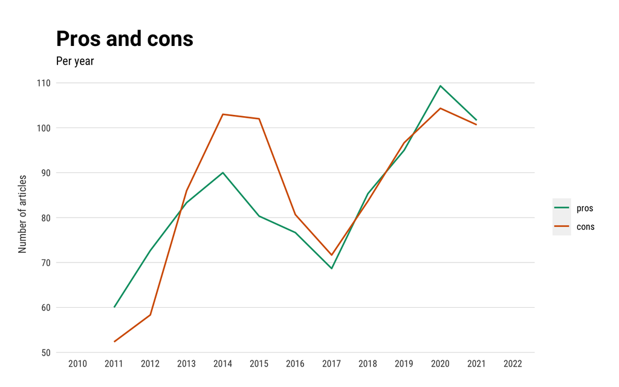

### Per quarter

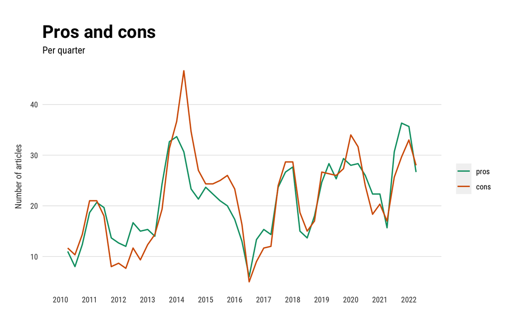

## Type of arguments

### Per year

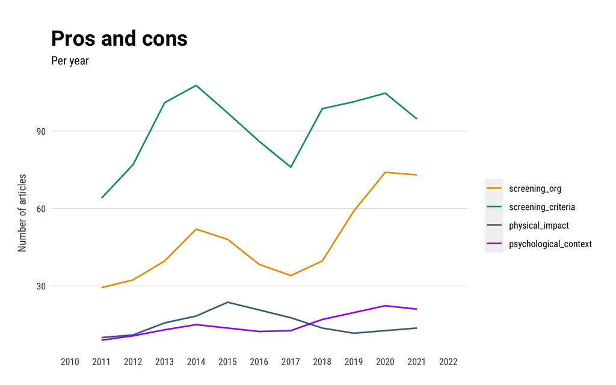

### Per quarter

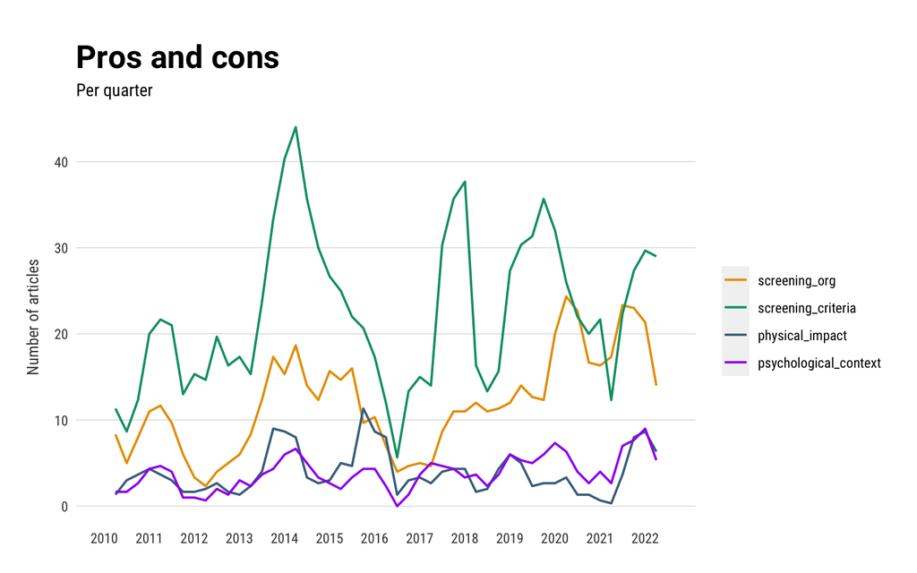

# RQ3: Contextualization

## Pro/con vs. current/innov

Are current measures framed differently from screening innovations?

### Freqs

|  | Con n | Con % | Pro n | Pro % |
| --- | --- | --- | --- | --- |
| Current | 977 | 90.55 | 898 | 84.4 |
| Innovation | 102 | 9.45 | 166 | 15.6 |

### Chi-square

```
##
                                                                    ##  Pearson's Chi-squared test with Yates' continuity correction
                                                                    ##
                                                                    ## data:  df$procon_method and df$procon_valence
                                                                    ## X-squared = 17.95, df = 1, p-value = 2.267e-05
```

```
##                 df$procon_valence
                                                                    ## df$procon_method  Negative  Positive
                                                                    ##       Current     1.072003 -1.079533
                                                                    ##       Innovation -2.835498  2.855415
```

## Pro/con vs. aspect type

Are pros more common for some types of arguments (e.g. effectivess) and cons for others (e.g. psychological)?

### Freqs

|  | Con n | Con % | Pro n | Pro % |
| --- | --- | --- | --- | --- |
| Physical impact | 148 | 13.72 | 47 | 4.42 |
| Psychological context | 150 | 13.90 | 43 | 4.04 |
| Screening criteria | 373 | 34.57 | 771 | 72.46 |
| Screening organization | 408 | 37.81 | 203 | 19.08 |

### Chi-square

```
##
                                                                    ##  Pearson's Chi-squared test
                                                                    ##
                                                                    ## data:  df$type_aspect and df$procon_valence
                                                                    ## X-squared = 318.79, df = 3, p-value < 2.2e-16
```

```
##                         df$procon_valence
                                                                    ## df$type_aspect            Negative  Positive
                                                                    ##   Physical impact         5.027654 -5.062969
                                                                    ##   Psychological context   5.358676 -5.396316
                                                                    ##   Screening criteria     -8.458461  8.517875
                                                                    ##   Screening organization  5.721996 -5.762188
```

# RQ4: Differences between screening types

## Pros and cons per screening

### All screening types

#### Freqs

|  | Cervical n | Cervical % | Breast n | Breast % | Colon n | Colon % | Lung n | Lung % | Prostate n | Prostate % |
| --- | --- | --- | --- | --- | --- | --- | --- | --- | --- | --- |
| Negative | 165 | 48.67 | 351 | 44.15 | 293 | 51.58 | 17 | 45.95 | 104 | 68.42 |
| Positive | 174 | 51.33 | 444 | 55.85 | 275 | 48.42 | 20 | 54.05 | 48 | 31.58 |

#### Chi-square

```
##
                                                                        ##  Pearson's Chi-squared test
                                                                        ##
                                                                        ## data:  df_ctype$procon_valence and df_ctype$cancer_type
                                                                        ## X-squared = 32.064, df = 4, p-value = 1.856e-06
```

```
##                        df_ctype$cancer_type
                                                                        ## df_ctype$procon_valence Baarmoederhalskanker Borstkanker Darmkanker Longkanker
                                                                        ##                Negative           -0.1333104  -2.0221003  0.8170437 -0.2805411
                                                                        ##                Positive            0.1311426   1.9892184 -0.8037576  0.2759791
                                                                        ##                        df_ctype$cancer_type
                                                                        ## df_ctype$procon_valence Prostaatkanker
                                                                        ##                Negative      3.3825756
                                                                        ##                Positive     -3.3275707
```

### BVO only

#### Freqs

|  | Cervical n | Cervical % | Breast n | Breast % | Colon n | Colon % |
| --- | --- | --- | --- | --- | --- | --- |
| Negative | 165 | 48.67 | 351 | 44.15 | 293 | 51.58 |
| Positive | 174 | 51.33 | 444 | 55.85 | 275 | 48.42 |

#### Chi-square

```
##
                                                                        ##  Pearson's Chi-squared test
                                                                        ##
                                                                        ## data:  df_current$procon_valence and df_current$cancer_type
                                                                        ## X-squared = 7.5613, df = 2, p-value = 0.02281
```

```
##                          df_current$cancer_type
                                                                        ## df_current$procon_valence Baarmoederhalskanker Borstkanker Darmkanker
                                                                        ##                  Negative            0.3045131  -1.3828720  1.4007793
                                                                        ##                  Positive           -0.2898375   1.3162261 -1.3332704
```

### BVO vs. new

#### Freqs

|  | BVO n | BVO % | Under debate n | Under debate % |
| --- | --- | --- | --- | --- |
| Negative | 809 | 47.53 | 121 | 64.02 |
| Positive | 893 | 52.47 | 68 | 35.98 |

#### Chi-square

```
##
                                                                        ##  Pearson's Chi-squared test with Yates' continuity correction
                                                                        ##
                                                                        ## data:  df_binary$procon_valence and df_binary$cancer_binary
                                                                        ## X-squared = 17.851, df = 1, p-value = 2.389e-05
```

```
##                         df_binary$cancer_binary
                                                                        ## df_binary$procon_valence        BVO Under debate
                                                                        ##                 Negative -0.9694930    2.9093339
                                                                        ##                 Positive  0.9537279   -2.8620245
```

## Current vs. innovation per screening

### All screening types

#### Freqs

|  | Cervical n | Cervical % | Breast n | Breast % | Colon n | Colon % | Lung n | Lung % | Prostate n | Prostate % |
| --- | --- | --- | --- | --- | --- | --- | --- | --- | --- | --- |
| Current | 325 | 95.87 | 679 | 85.41 | 508 | 89.44 | 32 | 86.49 | 134 | 88.16 |
| Innovation | 14 | 4.13 | 116 | 14.59 | 60 | 10.56 | 5 | 13.51 | 18 | 11.84 |

#### Chi-square

```
##
                                                                        ##  Pearson's Chi-squared test
                                                                        ##
                                                                        ## data:  df_ctype$procon_method and df_ctype$cancer_type
                                                                        ## X-squared = 26.585, df = 4, p-value = 2.412e-05
```

```
##                       df_ctype$cancer_type
                                                                        ## df_ctype$procon_method Baarmoederhalskanker Borstkanker  Darmkanker  Longkanker
                                                                        ##             Current              1.39440233 -0.99592598  0.17722822 -0.14526538
                                                                        ##             Innovation          -3.91376077  2.79533099 -0.49743811  0.40772590
                                                                        ##                       df_ctype$cancer_type
                                                                        ## df_ctype$procon_method Prostaatkanker
                                                                        ##             Current       -0.07567762
                                                                        ##             Innovation     0.21240936
```

### BVO only

#### Freqs

|  | Cervical n | Cervical % | Breast n | Breast % | Colon n | Colon % |
| --- | --- | --- | --- | --- | --- | --- |
| Current | 325 | 95.87 | 679 | 85.41 | 508 | 89.44 |
| Innovation | 14 | 4.13 | 116 | 14.59 | 60 | 10.56 |

#### Chi-square

```
##
                                                                        ##  Pearson's Chi-squared test
                                                                        ##
                                                                        ## data:  df_current$procon_method and df_current$cancer_type
                                                                        ## X-squared = 26.536, df = 2, p-value = 1.729e-06
```

```
##                         df_current$cancer_type
                                                                        ## df_current$procon_method Baarmoederhalskanker Borstkanker Darmkanker
                                                                        ##               Current               1.3739721  -1.0254400  0.1517044
                                                                        ##               Innovation           -3.8759398   2.8927395 -0.4279542
```

### BVO vs. new

#### Freqs

|  | BVO n | BVO % | Under debate n | Under debate % |
| --- | --- | --- | --- | --- |
| Current | 1512 | 88.84 | 166 | 87.83 |
| Innovation | 190 | 11.16 | 23 | 12.17 |

#### Chi-square

```
##
                                                                        ##  Pearson's Chi-squared test with Yates' continuity correction
                                                                        ##
                                                                        ## data:  df_binary$procon_method and df_binary$cancer_binary
                                                                        ## X-squared = 0.08629, df = 1, p-value = 0.7689
```

```
##                        df_binary$cancer_binary
                                                                        ## df_binary$procon_method         BVO Under debate
                                                                        ##              Current     0.04403388  -0.13214048
                                                                        ##              Innovation -0.12359280   0.37088737
```

## Type of aspect per screening

### All screening types

#### Freqs

|  | Cervical n | Cervical % | Breast n | Breast % | Colon n | Colon % | Lung n | Lung % | Prostate n | Prostate % |
| --- | --- | --- | --- | --- | --- | --- | --- | --- | --- | --- |
| Physical impact | 19 | 5.60 | 92 | 11.57 | 45 | 7.92 | 2 | 5.41 | 20 | 13.16 |
| Psychological context | 47 | 13.86 | 48 | 6.04 | 48 | 8.45 | 6 | 16.22 | 31 | 20.39 |
| Screening criteria | 130 | 38.35 | 425 | 53.46 | 315 | 55.46 | 23 | 62.16 | 92 | 60.53 |
| Screening organization | 143 | 42.18 | 230 | 28.93 | 160 | 28.17 | 6 | 16.22 | 9 | 5.92 |

#### Chi-square

```
##
                                                                        ##  Pearson's Chi-squared test
                                                                        ##
                                                                        ## data:  df_ctype$type_aspect and df_ctype$cancer_type
                                                                        ## X-squared = 118.66, df = 12, p-value < 2.2e-16
```

```
##                         df_ctype$cancer_type
                                                                        ## df_ctype$type_aspect     Baarmoederhalskanker Borstkanker  Darmkanker
                                                                        ##   Physical impact                 -2.28541744  1.98443073 -1.15780194
                                                                        ##   Psychological context            2.59329832 -3.18127895 -0.82505510
                                                                        ##   Screening criteria              -3.50540523  0.53532777  1.11247569
                                                                        ##   Screening organization           4.51590600 -0.02543333 -0.35876385
                                                                        ##                         df_ctype$cancer_type
                                                                        ## df_ctype$type_aspect      Longkanker Prostaatkanker
                                                                        ##   Physical impact        -0.79455027     1.50486011
                                                                        ##   Psychological context   1.32044223     4.34609340
                                                                        ##   Screening criteria      0.84898722     1.44132489
                                                                        ##   Screening organization -1.44216368    -5.28086426
```

### BVO only

#### Freqs

|  | Cervical n | Cervical % | Breast n | Breast % | Colon n | Colon % |
| --- | --- | --- | --- | --- | --- | --- |
| Physical impact | 19 | 5.60 | 92 | 11.57 | 45 | 7.92 |
| Psychological context | 47 | 13.86 | 48 | 6.04 | 48 | 8.45 |
| Screening criteria | 130 | 38.35 | 425 | 53.46 | 315 | 55.46 |
| Screening organization | 143 | 42.18 | 230 | 28.93 | 160 | 28.17 |

#### Chi-square

```
##
                                                                        ##  Pearson's Chi-squared test
                                                                        ##
                                                                        ## data:  df_current$type_aspect and df_current$cancer_type
                                                                        ## X-squared = 57.784, df = 6, p-value = 1.267e-10
```

```
##                         df_current$cancer_type
                                                                        ## df_current$type_aspect   Baarmoederhalskanker Borstkanker  Darmkanker
                                                                        ##   Physical impact                 -2.16563548  2.24136252 -0.97862421
                                                                        ##   Psychological context            3.46974234 -2.29969003  0.04014394
                                                                        ##   Screening criteria              -3.28814845  0.92392410  1.44718948
                                                                        ##   Screening organization           3.57534029 -1.20181966 -1.34028995
```

### BVO vs. new

#### Freqs

|  | BVO n | BVO % | Under debate n | Under debate % |
| --- | --- | --- | --- | --- |
| Physical impact | 156 | 9.17 | 22 | 11.64 |
| Psychological context | 143 | 8.40 | 37 | 19.58 |
| Screening criteria | 870 | 51.12 | 115 | 60.85 |
| Screening organization | 533 | 31.32 | 15 | 7.94 |

#### Chi-square

```
##
                                                                        ##  Pearson's Chi-squared test
                                                                        ##
                                                                        ## data:  df_binary$type_aspect and df_binary$cancer_binary
                                                                        ## X-squared = 58.601, df = 3, p-value = 1.17e-12
```

```
##                         df_binary$cancer_binary
                                                                        ## df_binary$type_aspect           BVO Under debate
                                                                        ##   Physical impact        -0.3325658    0.9979905
                                                                        ##   Psychological context  -1.4934850    4.4817717
                                                                        ##   Screening criteria     -0.5559051    1.6682055
                                                                        ##   Screening organization  1.7907809   -5.3739215
```

## Pro or con: BVO vs. debated screening

### Screening criteria

#### Freqs

|  | BVO n | BVO % | Under debate n | Under debate % |
| --- | --- | --- | --- | --- |
| Negative | 248 | 28.51 | 58 | 50.43 |
| Positive | 622 | 71.49 | 57 | 49.57 |

#### Chi-square

```
##
                                                                        ##  Pearson's Chi-squared test with Yates' continuity correction
                                                                        ##
                                                                        ## data:  df_criteria_bin$procon_valence and df_criteria_bin$cancer_binary
                                                                        ## X-squared = 21.796, df = 1, p-value = 3.032e-06
```

```
##                               df_criteria_bin$cancer_binary
                                                                        ## df_criteria_bin$procon_valence        BVO Under debate
                                                                        ##                       Negative -1.3548717    3.7265665
                                                                        ##                       Positive  0.9095446   -2.5016970
```

### Screening organization

#### Freqs

|  | BVO n | BVO % | Under debate n | Under debate % |
| --- | --- | --- | --- | --- |
| Negative | 343 | 64.35 | 11 | 73.33 |
| Positive | 190 | 35.65 | 4 | 26.67 |

#### Chi-square

```
##
                                                                        ##  Pearson's Chi-squared test with Yates' continuity correction
                                                                        ##
                                                                        ## data:  df_org_bin$procon_valence and df_org_bin$cancer_binary
                                                                        ## X-squared = 0.19675, df = 1, p-value = 0.6574
```

```
##                          df_org_bin$cancer_binary
                                                                        ## df_org_bin$procon_valence         BVO Under debate
                                                                        ##                  Negative -0.07061044   0.42090773
                                                                        ##                  Positive  0.09538272  -0.56857488
```

### Physical impact

#### Freqs

|  | BVO n | BVO % | Under debate n | Under debate % |
| --- | --- | --- | --- | --- |
| Negative | 114 | 73.08 | 17 | 77.27 |
| Positive | 42 | 26.92 | 5 | 22.73 |

#### Chi-square

```
##
                                                                        ##  Pearson's Chi-squared test with Yates' continuity correction
                                                                        ##
                                                                        ## data:  df_physical_bin$procon_valence and df_physical_bin$cancer_binary
                                                                        ## X-squared = 0.025482, df = 1, p-value = 0.8732
```

```
##                               df_physical_bin$cancer_binary
                                                                        ## df_physical_bin$procon_valence         BVO Under debate
                                                                        ##                       Negative -0.07550132   0.20105066
                                                                        ##                       Positive  0.12604954  -0.33565430
```

### Psychological context

#### Freqs

|  | BVO n | BVO % | Under debate n | Under debate % |
| --- | --- | --- | --- | --- |
| Negative | 104 | 72.73 | 35 | 94.59 |
| Positive | 39 | 27.27 | 2 | 5.41 |

#### Chi-square

```
##
                                                                        ##  Pearson's Chi-squared test with Yates' continuity correction
                                                                        ##
                                                                        ## data:  df_psychological_bin$procon_valence and df_psychological_bin$cancer_binary
                                                                        ## X-squared = 6.7962, df = 1, p-value = 0.009135
```

```
##
                                                                        ##                   BVO Under debate
                                                                        ##   Negative -0.6116763    1.2025104
                                                                        ##   Positive  1.1262561   -2.2141361
```

## Pro or con: BVO

### Screening criteria

#### Freqs

|  | Cervical n | Cervical % | Breast n | Breast % | Colon n | Colon % |
| --- | --- | --- | --- | --- | --- | --- |
| Negative | 23 | 17.69 | 120 | 28.24 | 105 | 33.33 |
| Positive | 107 | 82.31 | 305 | 71.76 | 210 | 66.67 |

#### Chi-square

```
##
                                                                        ##  Pearson's Chi-squared test
                                                                        ##
                                                                        ## data:  df_criteria$procon_valence and df_criteria$cancer_type
                                                                        ## X-squared = 11.076, df = 2, p-value = 0.003934
```

```
##                           df_criteria$cancer_type
                                                                        ## df_criteria$procon_valence Baarmoederhalskanker Borstkanker  Darmkanker
                                                                        ##                   Negative          -2.30924129 -0.10442875  1.60479329
                                                                        ##                   Positive           1.45814248  0.06594027 -1.01332731
```

### Screening organization

#### Freqs

|  | Cervical n | Cervical % | Breast n | Breast % | Colon n | Colon % |
| --- | --- | --- | --- | --- | --- | --- |
| Negative | 92 | 64.34 | 139 | 60.43 | 112 | 70 |
| Positive | 51 | 35.66 | 91 | 39.57 | 48 | 30 |

#### Chi-square

```
##
                                                                        ##  Pearson's Chi-squared test
                                                                        ##
                                                                        ## data:  df_org$procon_valence and df_org$cancer_type
                                                                        ## X-squared = 3.7634, df = 2, p-value = 0.1523
```

```
##                      df_org$cancer_type
                                                                        ## df_org$procon_valence Baarmoederhalskanker  Borstkanker   Darmkanker
                                                                        ##              Negative         -0.002542522 -0.740692597  0.890462885
                                                                        ##              Positive          0.003416134  0.995195179 -1.196426660
```

### Physical impact

#### Freqs

|  | Cervical n | Cervical % | Breast n | Breast % | Colon n | Colon % |
| --- | --- | --- | --- | --- | --- | --- |
| Negative | 15 | 78.95 | 59 | 64.13 | 40 | 88.89 |
| Positive | 4 | 21.05 | 33 | 35.87 | 5 | 11.11 |

#### Chi-square

```
##
                                                                        ##  Pearson's Chi-squared test
                                                                        ##
                                                                        ## data:  df_physical$procon_valence and df_physical$cancer_type
                                                                        ## X-squared = 9.794, df = 2, p-value = 0.007469
```

```
##                           df_physical$cancer_type
                                                                        ## df_physical$procon_valence Baarmoederhalskanker Borstkanker Darmkanker
                                                                        ##                   Negative            0.2993352  -1.0038213  1.2408006
                                                                        ##                   Positive           -0.4931573   1.6538045 -2.0442301
```

### Psychological context

#### Freqs

|  | Cervical n | Cervical % | Breast n | Breast % | Colon n | Colon % |
| --- | --- | --- | --- | --- | --- | --- |
| Negative | 35 | 74.47 | 33 | 68.75 | 36 | 75 |
| Positive | 12 | 25.53 | 15 | 31.25 | 12 | 25 |

#### Chi-square

```
##
                                                                        ##  Pearson's Chi-squared test
                                                                        ##
                                                                        ## data:  df_psychological$procon_valence and df_psychological$cancer_type
                                                                        ## X-squared = 0.57962, df = 2, p-value = 0.7484
```

```
##           df_psychological$cancer_type
                                                                        ##            Baarmoederhalskanker Borstkanker Darmkanker
                                                                        ##   Negative            0.1399433  -0.3231152  0.1846372
                                                                        ##   Positive           -0.2285265   0.5276449 -0.3015113
```